# WADEPS Tutorial : Clustering for Beginners

## Research Question: Which Factors in King County WA are Associated With High Crime?

Suppose that we are particularly interested in moving to King County WA, but want to know which cities or regions of this county are safest to live in. One logical way to deduce this information is to perform cluster analysis. In a nutshell, this method of analysis will allow us to group crime counts in King county data in such a way that help us to identify patterns and relationships between the frequency of certain crimes occurring and the population in King county in a given year. To do this, we first import our data.

## STEP 1: Upload the Data

Once we’ve set up our data so we can easily obtain observations only from King County, our next step is to upload it into R. Notice that before cleaning up the data (explained in the following section), we have 366 observations.

```r
#upload modified data from Step 0
library(readxl)
directory="C:/Users/eliza/OneDrive/Documents/WADEPS/Clustering Tutorials/WADEPS_TUT_CLUSTERING_DATA.xlsx"
data=read_excel(directory)

#identify all observations from modified data from King county
KING_data=data[which(data[,"King"]==1),]

#observe number of observations
dim(KING_data)[1]
```

```
## [1] 366
```

Observe the structure of our King county data. We are given the counts of different crimes and populations of King County in different years.

```r
col_names=c("IndexYear","Location","Population","Burglary","Murder","Robbery")
KING_data[1:10, names(KING_data) %in% col_names]
```

```
## # A tibble: 10 × 6
##    IndexYear Location                 Population Murder Burglary Robbery
##    <chr>     <chr>                         <dbl>  <dbl>    <dbl>   <dbl>
##  1 2012      Algona Police Department       3070      0       13       1
##  2 2013      Algona Police Department       3075      0       22       0
##  3 2014      Algona Police Department       3090      0       29       0
##  4 2015      Algona Police Department       3105      0       15       0
##  5 2016      Algona Police Department       3175      0       16       0
##  6 2017      Algona Police Department       3180      0       14       1
##  7 2018      Algona Police Department       3180      0       11       1
##  8 2019      Algona Police Department       3190      0        9       2
##  9 2020      Algona Police Department       3210      0       10       0
## 10 2021      Algona Police Department       3265      0       15       0
```

## STEP 2: Clean up the Data for Clustering

The next logical step after uploading the data is to clean it up before analysis. This intuitively means that we just aim to get rid of all samples that have missing information, or any variables that are not of the right form for clustering. To do this, we remove variables with word entries to ensure all variables in our data are numeric, and we remove als observations with at least one blank entry. In the “Rescaling” the data section below, we describe the importance of re-centering and scaling our observations so that they all lay within similar ranges in terms of minimum and maximum theft counts. This process involves first subtracting each crime count by the mean crime counts, and then dividing by the standard deviation of a variable (i.e. how much the given crime counts differ from their mean). Well, our binary variables created in STEP 0 only have values of 0 or 1, and hence have standard deviation of 0. Dividing by zero is “illegal” in math! Hence, we need to remove these binary variables from our data so we can center our data later on for clustering. This is our last “clean-up” step.

```r
#remove text columns
cols_to_remove=c("county","Location")
KING_data=KING_data[,!(names(KING_data) %in% cols_to_remove)]

#convert variables to numeric
KING_data=sapply(KING_data,as.numeric)

#remove rows with at least one blank entry
KING_data=KING_data[complete.cases(KING_data),]

#remove binary county variables since they all have standard deviation=0
cols_to_remove=c("Grant","Grays Harbor", "King", "Pierce", "Yakima")
KING_data=KING_data[,!(colnames(KING_data) %in% cols_to_remove)]

#observe new number of King observations
dim(KING_data)[1]
```

```
## [1] 364
```

Notice that after all of this clean-up, we only lost two observations. This is a good thing! It’s important to make sure that data left after cleaning is large enough to ensure we get reliable results in any analysis we do.

## Step 3: Visualize How Correlated Certain Factors Are in King County

In order to visualize how correlated certain crime variables in our King county data are, we use a correlation coefficient matrix. The idea is that the darker a given cell in this matrix, the more correlated its two associated variables are. The color of the cells here are determined using a correlation coefficient. Simply put, this is just a number between -1 and +1 that tells us how much two variables have in common. For instance, a pair of variables “Murder” and “Population” for King county are highly correlated if their coefficient is near +1 or -1, and not very correlated if their coefficient is near 0. Now, you may be wondering - How do we know if high correlation is “good” or “bad”? Well, this answer depends on the context of the data you’re using and the goal of your investigation. In this context, if we want to ensure we are moving to a WA county that is safest, we don’t want Population and Murder counts to be highly correlated. On the other hand, say we enjoy city-life, so we want to move to a highly populated county that has lots of job opportunities. In this case, we would want Population and Jobs to be highly correlated (near +1).

## STEP 4: Compute Correlation Coefficients for all Variables in King County Data

```r
#compute correlation coefficients
library(corrplot)
KING_coeff_mat=cor(KING_data)

#visualize the first six coefficients for the first five variables in the data
KING_coeff_mat[1:6,1:5]
```

```
##               IndexYear  Population      Total        Rate   PrsnTotal
## IndexYear   1.000000000 0.004725009 -0.0238048 -0.08117781 -0.01111561
## Population  0.004725009 1.000000000  0.9874593  0.16849970  0.98631674
## Total      -0.023804804 0.987459315  1.0000000  0.21632956  0.99522865
## Rate       -0.081177809 0.168499704  0.2163296  1.00000000  0.20685579
## PrsnTotal  -0.011115611 0.986316743  0.9952287  0.20685579  1.00000000
## PrsnRate   -0.036180000 0.266777771  0.3172503  0.87948159  0.32490808
```

Suppose we are particularly interested in exploring how correlated Population and the number of burglaries, murders, and robberies are in King county WA.

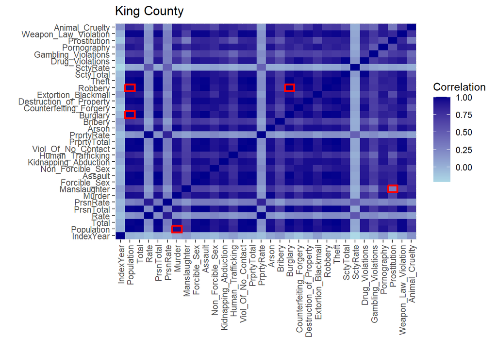

```r
library(ggplot2)

#compute list of variable names in King County data
cor_var=colnames(KING_coeff_mat)

#create a data frame to store coefficients for each pair of variables
cor_df=expand.grid(x = cor_var, y = cor_var)

#add coefficients to data frame
cor_df$r=as.vector(KING_coeff_mat)

#highlight cells in coefficient matrix with variables of interest

#first pair
row_name_1="Robbery"
col_name_1="Burglary"

#second pair
row_name_2="Burglary"
col_name_2="Population"

#third pair
row_name_3="Robbery"
col_name_3="Population"

#fourth pair
row_name_4="Population"
col_name_4="Murder"


#highlight cell with pair of variables not of interest (i.e. low correlation)

#fifth pair
row_name_5="Manslaughter"
col_name_5="Prostitution"

#construct coefficient matrix with highlighted coefficient pairs
king_matrix=ggplot(cor_df, aes(x = x, y = y, fill = r)) +
  geom_tile() +
  geom_tile(data = subset(cor_df, x == col_name_1 & y == row_name_1 | x == col_name_2 & y == row_name_2 | x == col_name_3 & y == row_name_3 | x == col_name_4 & y == row_name_4 | x == col_name_5 & y == row_name_5),
            color = "red", size = 1) +
  scale_fill_gradient(low = "lightblue", high = "darkblue") +
  labs(x = "", y = "", fill = "Correlation") +
  ggtitle("King County") +
  theme(axis.text.x = element_text(angle = 90, vjust = 0.5, hjust = 1))

#visualize matrix
king_matrix
```

As shown in our coefficient matrix, all of our variables of interest are highly correlated, since their cells are all dark blue (near +1). As well, we shown an instance of two variables Prostitution and Manslaughter that are not very correlated. A natural way to visually interpret the correlation between variables is their linear relationship. Two variables that are highly positively correlated have a positive linear relationship, while two that have a highly negative correlation have a negative linear relationship. See an example below.

[figure not shown]

```r
#plot variables with high positive correlation
plot(KING_data[,"Population"],KING_data[,"Burglary"],pch=16, col='black',xlab="
     Population",ylab="Robberies",main="King County, WA")
```

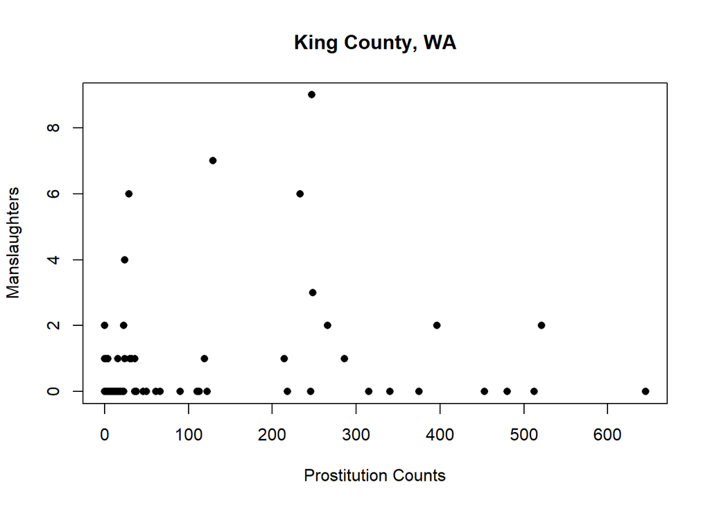

```r
#plot variables with nearly zero correlation
plot(KING_data[,"Prostitution"],KING_data[,"Manslaughter"],pch=16, col='black',
  ylab="Manslaughters",xlab="Prostitution Counts",main="King County, WA")
```

## Correlation Does Not Mean Causation

It is important to discuss a common misconception when exploring correlation between variables in data. Just because two variables are highly correlated, does NOT mean that an increase or decrease in one causes in increase or decrease in the other. In other words, two events can be related, but this does not necessarily mean that one event causes the other. For instance, raining causes one to get wet, while raining and wearing rain boots are just correlated. This is an important discrepancy to understand when analyzing our cluster results. Just because higher populations and higher robbery occurrences are related does not necessarily imply that larger populations cause more robberies in King County WA to occur.

## STEP 5: Compute the Significance of Correlations

Now we know that we should keep these variables for clustering. The next step is to ensure that the correlations we are computing are significant. To do this, we need to compute a probability value, also called a p-value. This quantity essentially just tells us the probability that a given correlation coefficient is close to zero. Since we want our variables to be highly correlated, we want this probability to be low (close to 0).

```r
#initialize matrix to store variables, their coefficients, and their p-values
rows=c("Robbery","Robbery","Burglary","Population")
cols=c("Population","Burglary","Population","Murder")
KING_coeffs=KING_coeff_mat[rows,cols]

#convert to data frame
KING_table=data.frame(matrix(0, nrow = 4, ncol = 2))
colnames(KING_table)=c("Coefficient","p-value")
rownames(KING_table)=c("Robbery vs Population","Robbery vs Burglary","Burglary vs Population","Population vs Murder")

#compute p-values
KING_table["Robbery vs Population","p-value"]=cor.test(KING_data[,"Robbery"],KING_data[,"Population"])$p.value
KING_table["Robbery vs Burglary","p-value"]=cor.test(KING_data[,"Robbery"],KING_data[,"Burglary"])$p.value
KING_table["Burglary vs Population","p-value"]=cor.test(KING_data[,"Burglary"],KING_data[,"Population"])$p.value
KING_table["Population vs Murder","p-value"]=cor.test(KING_data[,"Population"],KING_data[,"Murder"])$p.value

#store p-values in data frame
KING_table["Robbery vs Population","Coefficient"]=KING_coeffs["Robbery","Population"]
KING_table["Robbery vs Burglary","Coefficient"]=KING_coeffs["Robbery","Burglary"]
KING_table["Burglary vs Population","Coefficient"]=KING_coeffs["Burglary","Population"]
KING_table["Population vs Murder","Coefficient"]=KING_coeffs["Population","Murder"]

#visualize data frame
KING_table
```

```
##                        Coefficient       p-value
## Robbery vs Population    0.9670261 4.028475e-217
## Robbery vs Burglary      0.9929740  0.000000e+00
## Burglary vs Population   0.9734810 5.432012e-234
## Population vs Murder     0.9448923 1.248340e-177
```

As shown, we’ve successfully verified that all of our variable-pairs of interest are highly correlated, and the probability that these correlations are close to zero is low. We can now confidently use these variable for clustering.

## STEP 6: Rescale the Data for Clustering

The way cluster analysis works is by grouping data into groups, called clusters, where a given data point is assigned to one cluster if it its distance to the mean of that cluster is small.Because this process involves computing distances, we need to ensure that all variables in our data lay within close ranges. For instance, as is, the Population variable has a much higher maximum than the maximum of the Murder variable. This could make clustering less efficient. See an example of two variables with vastly different ranges in our data.

```r
#visualize range of Population size in King County data
range(KING_data[,"Population"])
```

```
## [1]       0 2345900
```

```r
#visualize range of Population size in King County data
range(KING_data[,"Murder"])
```

```
## [1]   0 124
```

To close these range-gaps, a common method is to rescale the data. This is a fancy way of saying to reconstruct the values of each variable in the King county data so that they all fall within the same range of values.

```r
#re-scale the data
KING_data_scaled=scale(KING_data)

#visualize new ranges after re-scaling

#put ranges of each variable of interest in data frame
new_ranges=as.data.frame(rbind(range(KING_data_scaled[,"Population"]),
      range(KING_data_scaled[,"Murder"]),
      range(KING_data_scaled[,"Robbery"]),
      range(KING_data_scaled[,"Burglary"])))
colnames(new_ranges)=c("min","max")
rownames(new_ranges)=c("Population","Murder","Robbery","Burglary")

new_ranges
```

```
##                   min      max
## Population -0.3270725 6.683785
## Murder     -0.2904204 8.626869
## Robbery    -0.3024891 6.046337
## Burglary   -0.3074428 6.154334
```

## STEP 7: Choosing the Optimal Number of Clusters

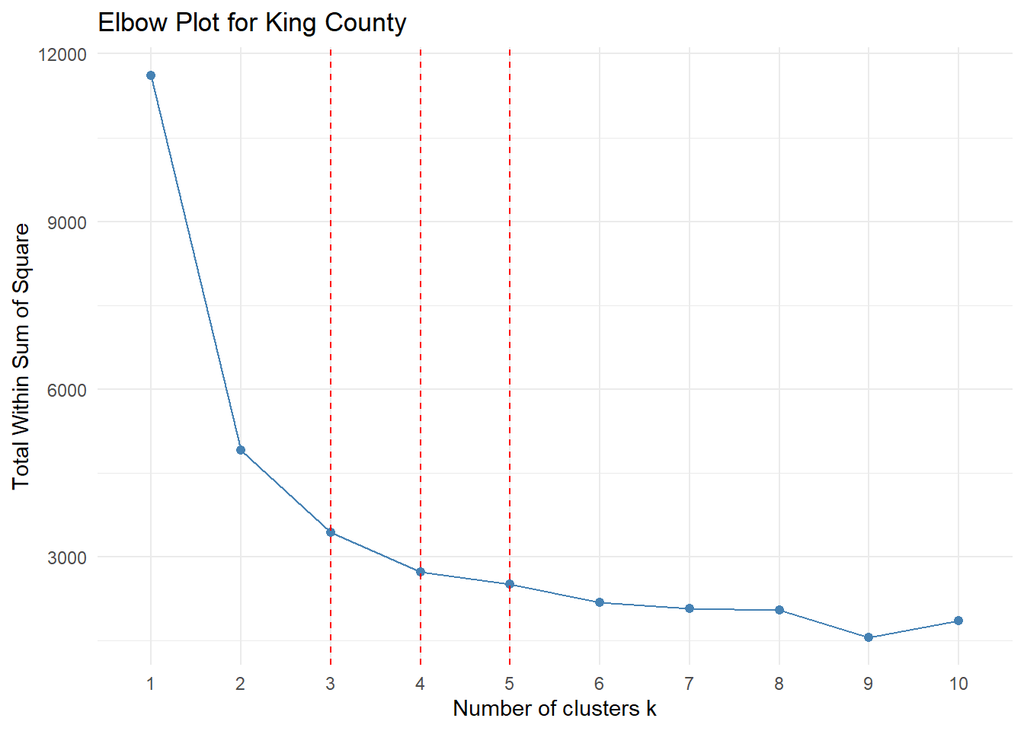

```r
library(cluster)
library(factoextra)

set.seed(123)
King_elbowplt=fviz_nbclust(KING_data_scaled, kmeans, method = "wss", k.max = 10) +
  ggtitle("Elbow Plot for King County") +
  theme_minimal() +
  geom_vline(xintercept = c(3,4,5), linetype = "dashed", color = "red")

King_elbowplt
```

Not all elbow plots look like an elbow though. For this situation, there are many other methods to select a choice for k. See the intermediate/advanced clustering tutorial for Public for a tutorial on how to use these.

Now that we have options for k=3, k=4, or k=5, we can plot what the clusters look like for each of these values.

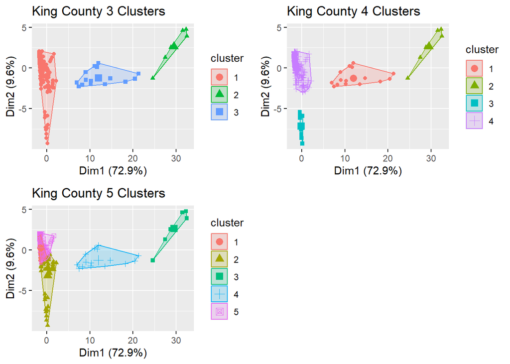

```r
library(gridExtra)

#k=3
KING_cluster=kmeans(KING_data_scaled, centers = 3)
King_clustersplt_3=fviz_cluster(KING_cluster, geom = "point", data = KING_data_scaled) + ggtitle("King County 3 Clusters")

#k=4
KING_cluster=kmeans(KING_data_scaled, centers = 4)
King_clustersplt_4=fviz_cluster(KING_cluster, geom = "point", data = KING_data_scaled) + ggtitle("King County 4 Clusters")

#k=5
KING_cluster=kmeans(KING_data_scaled, centers = 5)
King_clustersplt_5=fviz_cluster(KING_cluster, geom = "point", data = KING_data_scaled) + ggtitle("King County 5 Clusters")

#plot all 3
grid.arrange(King_clustersplt_3, King_clustersplt_4, King_clustersplt_5, nrow = 2, ncol = 2)
```

## STEP 8: Analyze Cluster Results

```r
#redefine cluster results for k=3
KING_cluster=kmeans(KING_data_scaled, centers = 4)
King_clustersplt_3=fviz_cluster(KING_cluster, geom = "point", data = KING_data_scaled) + ggtitle("King County 4 Clusters")

#initialize cluster results in data frame
KING_cluster_assignments=as.data.frame(KING_cluster$cluster)
colnames(KING_cluster_assignments)="Cluster Assignment"
KING_data=cbind(KING_data[,c("Robbery","Burglary","Murder","Population")],KING_cluster_assignments)

#extract points from each cluster
KING_cluster_1=KING_data[which(KING_data["Cluster Assignment"]==1),]
KING_cluster_2=KING_data[which(KING_data["Cluster Assignment"]==2),]
KING_cluster_3=KING_data[which(KING_data["Cluster Assignment"]==3),]
KING_cluster_4=KING_data[which(KING_data["Cluster Assignment"]==4),]

#fill in data frame
KING_cluster_statistics_table=data.frame(matrix(0, nrow = 4, ncol = 6))
colnames(KING_cluster_statistics_table)=c("Cluster", "Size", "Avg Population", "Avg Murder", "Avg Burglary", "Avg Robbery")

#add cluster 1 statistics
cluster_1_size=dim(KING_cluster_1)[1]
cluster_1_pop_avg=mean(KING_cluster_1[,"Population"])
cluster_1_murder_avg=mean(KING_cluster_1[,"Murder"])
cluster_1_burglary_avg=mean(KING_cluster_1[,"Burglary"])
cluster_1_robbery_avg=mean(KING_cluster_1[,"Robbery"])

KING_cluster_statistics_table[1,]=c(1,cluster_1_size,cluster_1_pop_avg, cluster_1_murder_avg, cluster_1_burglary_avg, cluster_1_robbery_avg)

#add cluster 2 stats
cluster_2_size=dim(KING_cluster_2)[1]
cluster_2_pop_avg=mean(KING_cluster_2[,"Population"])
cluster_2_murder_avg=mean(KING_cluster_2[,"Murder"])
cluster_2_burglary_avg=mean(KING_cluster_2[,"Burglary"])
cluster_2_robbery_avg=mean(KING_cluster_2[,"Robbery"])

KING_cluster_statistics_table[2,]=c(2,cluster_2_size,cluster_2_pop_avg, cluster_2_murder_avg, cluster_2_burglary_avg, cluster_2_robbery_avg)

#add cluster 3 stats
cluster_3_size=dim(KING_cluster_3)[1]
cluster_3_pop_avg=mean(KING_cluster_3[,"Population"])
cluster_3_murder_avg=mean(KING_cluster_3[,"Murder"])
cluster_3_burglary_avg=mean(KING_cluster_3[,"Burglary"])
cluster_3_robbery_avg=mean(KING_cluster_3[,"Robbery"])

KING_cluster_statistics_table[3,]=c(3,cluster_3_size,cluster_3_pop_avg, cluster_3_murder_avg, cluster_3_burglary_avg, cluster_3_robbery_avg)

#add cluster 4 stats
cluster_4_size=dim(KING_cluster_4)[1]
cluster_4_pop_avg=mean(KING_cluster_4[,"Population"])
cluster_4_murder_avg=mean(KING_cluster_4[,"Murder"])
cluster_4_burglary_avg=mean(KING_cluster_4[,"Burglary"])
cluster_4_robbery_avg=mean(KING_cluster_4[,"Robbery"])

KING_cluster_statistics_table[4,]=c(4,cluster_4_size,cluster_4_pop_avg, cluster_4_murder_avg, cluster_4_burglary_avg, cluster_4_robbery_avg)

#visualize averages for each variable of interest in each cluster
KING_cluster_statistics_table
```

```
##   Cluster Size Avg Population Avg Murder Avg Burglary Avg Robbery
## 1       1    6     2178019.83 88.1666667   15443.8333  2751.16667
## 2       2  284       29110.17  0.5598592     110.8134    13.55634
## 3       3   58       67823.84  4.0344828     562.0517   108.37931
## 4       4   16      910472.00 34.2500000    9329.3750  1753.50000
```

We can also visualize these averages in a bar plot.

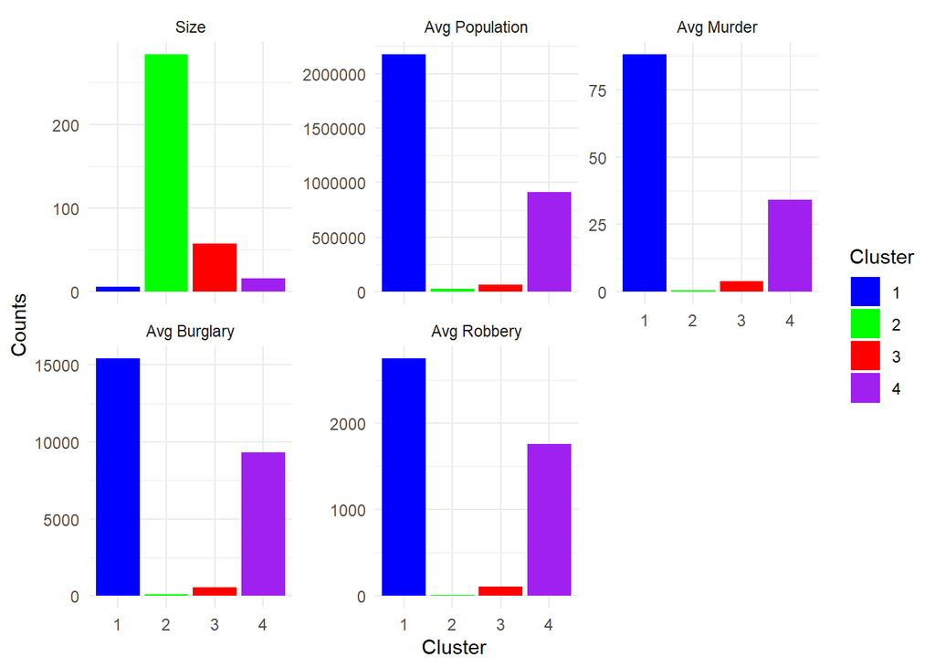

```r
library(reshape2)

# Create the data frame
KING_cluster_statistics_table=as.data.frame(KING_cluster_statistics_table)

#Convert Cluster to factor for plotting
KING_cluster_statistics_table$Cluster=factor(KING_cluster_statistics_table$Cluster)

#Reshape the data for plotting
KING_cluster_statistics_long=melt(KING_cluster_statistics_table, id.vars = "Cluster")

#Rename the columns for clarity
colnames(KING_cluster_statistics_long)=c("Cluster", "Statistic", "Value")

#plot cluster statistics as bars
ggplot(KING_cluster_statistics_long, aes(x = Cluster, y = Value, fill = Cluster)) +
  geom_bar(stat = "identity", position = "dodge") +
  labs(x = "Cluster", y = "Counts", fill = "Cluster") +
  theme_minimal() +
  scale_fill_manual(values = c("blue", "green", "red","purple")) +
  facet_wrap(~ Statistic, scales = "free_y")
```

We can also visualize the cluster assignments and the correlation between each pair of variables of interest.

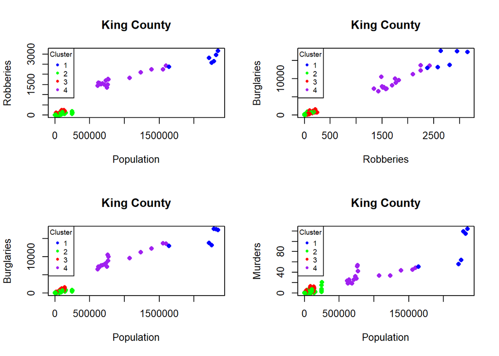

```r
library(gridExtra)
par(mfrow=c(2,2))

cluster=KING_data[,5]
legend_labels=sort(unique(cluster))
cluster_colors=c("blue","green","red","purple")

plot(KING_data[,"Population"],KING_data[,"Robbery"],pch=16,xlab="Population",ylab="Robberies",main="King County",col = cluster_colors[cluster])
legend("topleft", legend = legend_labels, col = cluster_colors, pch = 16, title = "Cluster",cex=0.7)

plot(KING_data[,"Robbery"],KING_data[,"Burglary"],pch=16,xlab="Robberies",ylab="Burglaries",main="King County",col = cluster_colors[cluster])
legend("topleft", legend = legend_labels, col = cluster_colors, pch = 16, title = "Cluster",cex=0.7)

plot(KING_data[,"Population"],KING_data[,"Burglary"],pch=16,xlab="Population",ylab="Burglaries",main="King County",col = cluster_colors[cluster])
legend("topleft", legend = legend_labels, col = cluster_colors, pch = 16, title = "Cluster",cex=0.7)

plot(KING_data[,"Population"],KING_data[,"Murder"],pch=16,xlab="Population",ylab="Murders",main="King County",col = cluster_colors[cluster])
legend("topleft", legend = legend_labels, col = cluster_colors, pch = 16, title = "Cluster",cex=0.7)
```

## Answering Our Research Question

Based on both our bar cluster charts and scatterplots, we can see that higher populations are clustered with greater crime counts for burglary, robbery, and murder. This indicates that larger populations are related to increased crimes in King counted. So, when choosing which cities in King County, WA to live in, this suggests that we choose those that are less populated, as these are associated with less crime based on our clustering and correlation results.